# 7_income

Jen Richmond

13/02/2021

```r
library(tidyverse)
library(kableExtra)
library(gt)
library(DT)
```

# read in the data

This week the Tidy Tuesday dataset is about income disparities in the US. I am particularly interest in the student debt dataset.

```r
debt <- read_csv(here::here("data", "debt.csv"))
glimpse(debt)
```

```
## Rows: 30
## Columns: 4
## $ year          <dbl> 2016, 2016, 2016, 2013, 2013, 2013, 2010, 2010, 2010, 2…
## $ race          <chr> "White", "Black", "Hispanic", "White", "Black", "Hispan…
## $ loan_debt     <dbl> 11108.4100, 14224.7700, 7493.9990, 8363.6050, 10302.660…
## $ loan_debt_pct <dbl> 0.3367511, 0.4183588, 0.2189689, 0.2845555, 0.4122773, …
```

Looks like year is numeric, make it a factor so that it works better in the plot

```r
debt$year <- as_factor(debt$year)
```

Looks like this df average family student loan debt for aged 25-55, by race and year normalized to 2016 dollars. Lets plot debt over time by race.

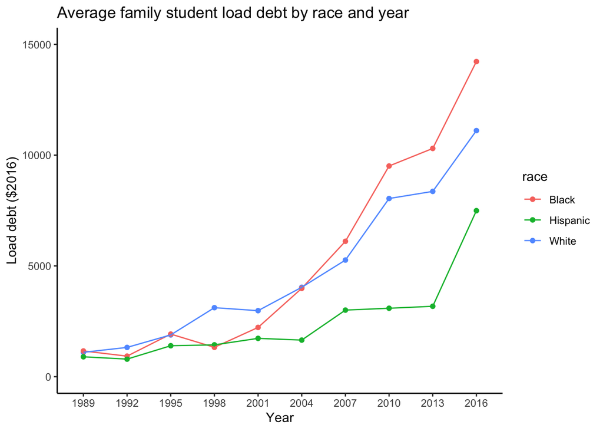

```r
debt %>%
  ggplot(aes(x = year, y = loan_debt, colour = race, group = race)) +
  geom_point() +
  geom_line() +
  theme_classic() +
  scale_y_continuous(limits = c(0,15000)) +
  labs(title = "Average family student load debt by race and year",
       y = "Load debt ($2016)",
       x = "Year")
```

OK the goal is to practice making tables, lets average this data into something that is table worthy.

```r
summary <- debt %>%
  group_by(year) %>%
  summarise(meandebt = mean(loan_debt))

summary
```

```
## # A tibble: 10 x 2
##    year  meandebt
##  * <fct>    <dbl>
##  1 1989     1053.
##  2 1992     1014.
##  3 1995     1735.
##  4 1998     1959.
##  5 2001     2311.
##  6 2004     3225.
##  7 2007     4793.
##  8 2010     6880.
##  9 2013     7281.
## 10 2016    10942.
```

I know that there are several packages that are usful for making tables in R. My goal was to try them out and work out what the pros/cons are

1. [kableExtra](https://cran.r-project.org/web/packages/kableExtra/vignettes/awesome_table_in_html.html)
2. [gt](https://gt.rstudio.com/)
3. [DT](https://rstudio.github.io/DT/)

## Option 1 kableExtra

Pipe your dataframe into the kbl() function and you get a basic html table.

The kbl() function gets a basic html table. Add kable styling to get a bootstrap theme.

```r
summary %>%
  kbl()
```

| year | meandebt |
| --- | --- |
| 1989 | 1052.853 |
| 1992 | 1013.949 |
| 1995 | 1735.111 |
| 1998 | 1959.001 |
| 2001 | 2311.100 |
| 2004 | 3224.881 |
| 2007 | 4793.357 |
| 2010 | 6880.418 |
| 2013 | 7281.225 |
| 2016 | 10942.393 |

```r
summary %>%
  kbl() %>%
  kable_styling()
```

| year | meandebt |
| --- | --- |
| 1989 | 1052.853 |
| 1992 | 1013.949 |
| 1995 | 1735.111 |
| 1998 | 1959.001 |
| 2001 | 2311.100 |
| 2004 | 3224.881 |
| 2007 | 4793.357 |
| 2010 | 6880.418 |
| 2013 | 7281.225 |
| 2016 | 10942.393 |

It is weird that in each of these options, when I run the Rmd chunk it doesn’t display the contents of the table. I just get a white box. But… when I knit the document, they render just fine. Not sure what is going on with that.

I wonder how you make it not so wide, take up an excessive amount of space…

## Option 2 gt (aka great tables)

```r
summary %>%
  gt()
```

| year | meandebt |
| --- | --- |
| 1989 | 1052.853 |
| 1992 | 1013.949 |
| 1995 | 1735.111 |
| 1998 | 1959.001 |
| 2001 | 2311.100 |
| 2004 | 3224.881 |
| 2007 | 4793.357 |
| 2010 | 6880.418 |
| 2013 | 7281.225 |
| 2016 | 10942.393 |

oooo that is prettier. It appears when i run the chunk and only takes up the necessary space. It is perhaps a little skinny though…

## Option 3 DT

```r
summary %>%
  DT::datatable()
```

|  | year | meandebt |
| --- | --- | --- |
| 1 | 1989 | 1052.85253333333 |
| 2 | 1992 | 1013.9488 |
| 3 | 1995 | 1735.111 |
| 4 | 1998 | 1959.00133333333 |
| 5 | 2001 | 2311.1 |
| 6 | 2004 | 3224.88066666667 |
| 7 | 2007 | 4793.35733333333 |
| 8 | 2010 | 6880.41833333333 |
| 9 | 2013 | 7281.225 |
| 10 | 2016 | 10942.393 |

OK that one seems nice. Not too big (or too skinny) and the search function could be useful if you were dealing with big tables. The decimal places are a bit of a problem though.

# Challenges/Successes

- I got the data summary to display as a table using 3 different packages (yay!), but each one as its own problems that I will need to dig into a little more. I like the kableExtra one (except it is annoying that it won’t display when I run the chunk). I like gt(), but I need to work out how to make it take up a little more room on the page. DT() is also nice, but it would be good if it would deal with those decimal places a bit more consistently.

# Next steps

So far I have piped my data into the main table function for each of these packages and ended up with the default settings. Next I need to look at the documentaion a little more closely and work out whether there are arguments I can use to make the kableExtra table display properly, make the gt() one take up more room, and fix the decimal places in the DT() table.